# Exploratory data analysis: RateBeer dataset

```r
#load libraries
library(data.table)
library(scales)
library(ggplot2)
library(stargazer)
library(ggthemes)
library(here)
library(forcats)
# set the working directory to be the location of your data file
setwd("/Users/dproserp/Library/CloudStorage/Dropbox/teaching/mkt566-2025/w3/beer-case")
```

In this exercise, we will work with a dataset of beer reviews from RateBeer (you can download it here), and perform some exploratory data analysis.

Let’s start by exploring the data and familiarizing with its structure:

```r
beer = fread("w3-ratebeer-sampled.csv.gz")
head(beer)
```

| beer_name | beer_beerId | beer_brewerId | beer_ABV | beer_style | review_appearance | review_aroma | review_palate | review_taste | review_overall | review_time | review_profileName |
| --- | --- | --- | --- | --- | --- | --- | --- | --- | --- | --- | --- |
| John Harvards Fancy Lawnmower Beer | 64125 | 8481 | 5.4 | Klsch | 2/5 | 4/10 | 2/5 | 4/10 | 8/20 | 1157587200 | hopdog |
| Barley Island Dirty &quot;Old&quot; Helen Sour Ale | 114513 | 3228 | - | Sour Ale/Wild Ale | 4/5 | 8/10 | 4/5 | 8/10 | 17/20 | 1266019200 | MI2CA |
| Barley Island Sinister Minister Belgian Black Ale | 77833 | 3228 | 6.7 | Traditional Ale | 3/5 | 6/10 | 3/5 | 6/10 | 16/20 | 1237420800 | emacgee |
| Barley Island Sinister Minister Belgian Black Ale | 77833 | 3228 | 6.7 | Traditional Ale | 4/5 | 6/10 | 4/5 | 6/10 | 14/20 | 1229040000 | after4ever |
| Barley Island Sinister Minister Belgian Black Ale | 77833 | 3228 | 6.7 | Traditional Ale | 3/5 | 6/10 | 3/5 | 6/10 | 12/20 | 1222041600 | Sparky |
| Barley Island Sinister Minister Belgian Black Ale | 77833 | 3228 | 6.7 | Traditional Ale | 3/5 | 5/10 | 3/5 | 6/10 | 13/20 | 1221264000 | jsquire |

1. How many variables are in the data?

```r
ncol(beer)
```

```
## [1] 12
```

2. How many rows?

```r
nrow(beer)
```

```
## [1] 292680
```

Now, let’s focus on some specific variables:

3. Explore the values of beer_style, do you see anything strange or unusual?

**SOLUTION**: Yes, there are non-beer drinks in the dataset, such as “Cider” and “Mead”. We will need to filter these out later.

```r
unique(beer$beer_style)
```

```
##  [1] "Klsch"                           "Sour Ale/Wild Ale"
##  [3] "Traditional Ale"                 "Belgian Ale"
##  [5] "India Pale Ale &#40;IPA&#41;"    "Brown Ale"
##  [7] "Porter"                          "Sweet Stout"
##  [9] "Golden Ale/Blond Ale"            "Stout"
## [11] "Scotch Ale"                      "Saison"
## [13] "Dunkel"                          "American Pale Ale"
## [15] "Belgian White &#40;Witbier&#41;" "Belgian Strong Ale"
## [17] "Wheat Ale"                       "Abt/Quadrupel"
## [19] "Premium Lager"                   "Imperial/Strong Porter"
## [21] "Pale Lager"                      "Fruit Beer"
## [23] "Amber Ale"                       "English Pale Ale"
## [25] "Spice/Herb/Vegetable"            "Pilsener"
## [27] "German Hefeweizen"               "Premium Bitter/ESB"
## [29] "Barley Wine"                     "Doppelbock"
```

[output cut: 30 more lines]

4. Explore the beer_ABV variable, do you see anything unusual?

**SOLUTION**: Yes, there are some values that are not numeric, such as “_“. Also, there are beers with very high ABV values.

5. What does the “_” value mean in the beer_ABV variable?

**SOLUTION**: The “_” character indicates that the ABV value is missing but it does not seem to be zero (since non-alcholic beer have ABV). We will need to handle these missing values appropriately.

6. Explore the rating (review_XXX) variables. Are you able to compute the mean? If not, what is the issue?

**SOLUTON**: The rating variables (review_overall, review_taste, etc.) are currently stored as character strings, which prevents us from computing the mean directly. We need to convert them to numeric format first.

7. Explore the variable review_time. What do you notice? How can you convert it to a date format?

**SOLUTION**: The review_time variable is in Unix timestamp format, which represents the number of seconds since January 1, 1970. We can convert it to a date format using the `as.POSIXct` function in R.

Now that we are familiar with the data, let’s try to visualize it and answer some questions. Before starting, remove non-beers drinks from the dataset, and convert all variables with prefix “review_” and beer_ABV to numerical variables.

```r
# fix a few things

#conver timestamp to datatime
beer[, datetime:= as.POSIXct(review_time, origin = "1970-01-01", tz = "UTC")]
#remove non-beers drinks
beer = beer[!grepl("Sak|Cider|Mead|Kombucha|Wine|Liquor", beer_style)]
#convert all review_ variables to numeric
for (col in c("review_overall", "review_aroma", "review_appearance", "review_palate", "review_taste")) {
  beer[, (col) := as.numeric(sub("/.*", "", get(col)))]
}
# conver abv to numeric
beer[, beer_ABV := as.numeric(beer_ABV)]
```

8. Plot the (ordered) distribution of reviews by beer_style. Which one is the most and least popular beer?

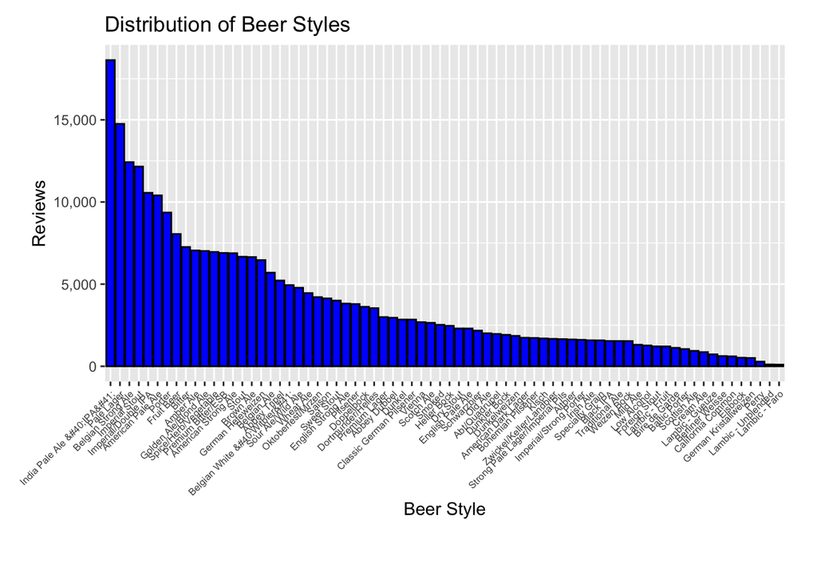

```r
beer$beer_style <- fct_infreq(beer$beer_style)
ggplot(data = beer) +
  geom_bar(mapping = aes(x = beer_style), fill = "blue", color = "black") +
  labs(title = "Distribution of Beer Styles", x = "Beer Style", y = "Reviews") +
  theme(axis.text.x = element_text(angle = 45, hjust = 1, size= 6),
        plot.margin  = margin(t = 10, r = 20, b = 40, l = 20)) +
  scale_y_continuous(labels = comma_format())
```

9. Plot the distribution of beer_ABV for all beers. Does it look like you would expect? Are there any outliers? Which one is the beer with the highest ABV?

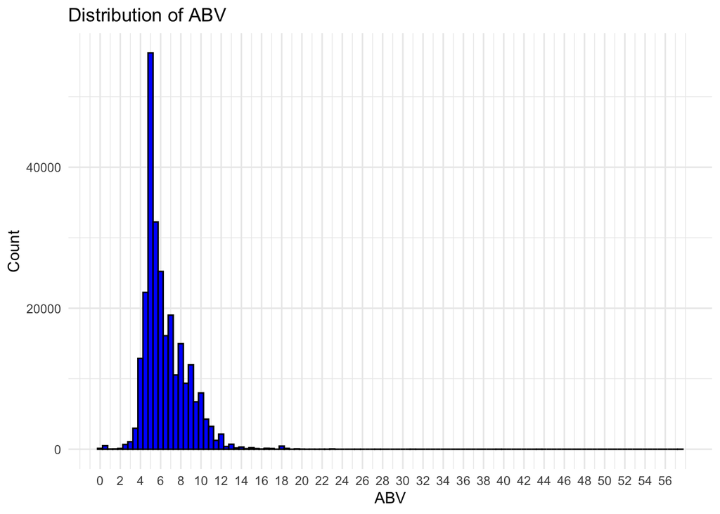

```r
ggplot(data = beer) +
  geom_histogram(mapping = aes(x = beer_ABV), binwidth = 0.5, fill = "blue", color = "black") +
  labs(title = "Distribution of ABV", x = "ABV", y = "Count") +
  scale_x_continuous(breaks = seq(0, max(beer$beer_ABV, na.rm = TRUE), 2)) +
  theme_minimal()
```

```r
# Example: Find outliers in the ABV variable
Q1 <- quantile(beer$beer_ABV, 0.25, na.rm = TRUE)
Q3 <- quantile(beer$beer_ABV, 0.75, na.rm = TRUE)
IQR <- Q3 - Q1
# Outliers are values below Q1 - 1.5*IQR or above Q3 + 1.5*IQR
lower_bound <- Q1 - 1.5 * IQR
upper_bound <- Q3 + 1.5 * IQR

outliers = unique(beer[beer_ABV < lower_bound | beer_ABV > upper_bound, .(beer_name, beer_ABV)])
outliers
```

| beer_name | beer_ABV |
| --- | --- |
| Lucky Bucket Certified Evil 2009 | 12.50 |
| Alt Platz Alt Krbis Pumpkin Ale | 16.50 |
| Parish Bazs Bonce Blower &#40;BBB&#41; | 12.00 |
| Twains Stormys Trippel | 12.00 |
| Sonoran 100 | 19.50 |
| Sonoran 200 | 19.37 |
| Papago Oak Aged Oh Brother | 12.50 |
| Craftsman Aurora Borealis | 13.00 |
| Craftsman Eye of the Goat | 14.00 |
| Brodies Elizabethan | 22.00 |

[output cut: 477 more lines]

```r
# beer with max ABV
max_abv_beer <- beer[which.max(beer$beer_ABV), .(beer_name, beer_style, beer_ABV)]
max_abv_beer
```

| beer_name | beer_style | beer_ABV |
| --- | --- | --- |
| Schorschbru Schorschbock 57% finis coronat opus | Eisbock | 57.7 |

10. Plot the distribution of average beer_ABV by beer_style. Which beer_style has the most and least ABV content?

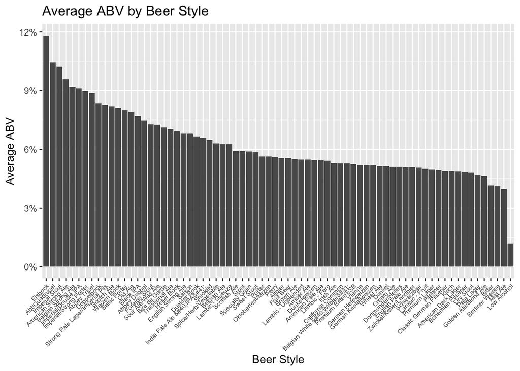

```r
avg.abv = beer[, .(beer_ABV = mean(as.numeric(beer_ABV), na.rm = TRUE)), by = beer_style]
ggplot(data = avg.abv) +
  geom_bar(mapping = aes(x = reorder(beer_style, -beer_ABV), y = beer_ABV), stat = "identity") +
  labs(title = "Average ABV by Beer Style", x = "Beer Style", y = "Average ABV") +
  theme(axis.text.x = element_text(angle = 45, hjust = 1, size = 6)) +
  scale_y_continuous(labels = scales::percent_format(scale = 1))
```

Next, let’s look at ratings:

11. Plot the average review_overall by beer_style. Which one is the highest- and lowest-rated style?

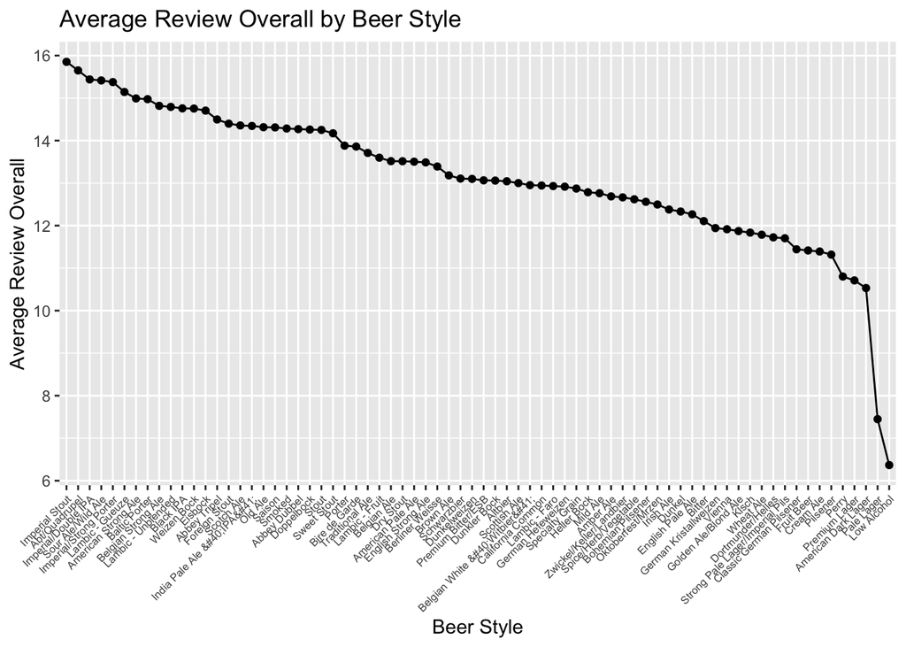

```r
avg.review = beer[, .(review_overall = mean(review_overall, na.rm = TRUE)), by = beer_style]
ggplot(data = avg.review, aes(x = reorder(beer_style, -review_overall), y = review_overall, group = 1)) +
  geom_line() + geom_point() +
  labs(title = "Average Review Overall by Beer Style", x = "Beer Style", y = "Average Review Overall") +
  theme(axis.text.x = element_text(angle = 45, hjust = 1, size = 6)) +
  scale_y_continuous(labels = scales::number_format(scale = 1))
```

12. Plot the average review_taste by beer_style. Which one is the highest- and lowest-rated style?

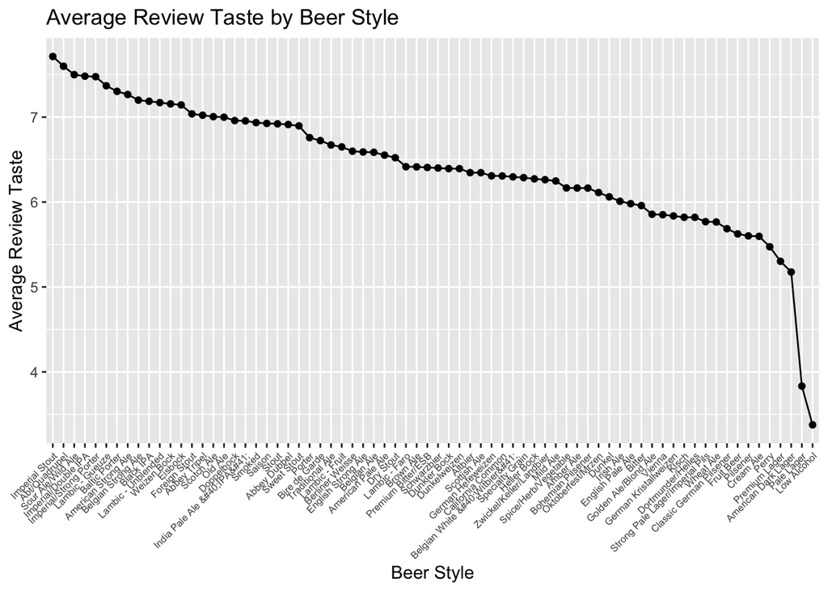

```r
avg.taste = beer[, .(review_taste = mean(review_taste, na.rm = TRUE)), by = beer_style]
ggplot(data = avg.taste, aes(x = reorder(beer_style, -review_taste), y = review_taste, group = 1)) +
  geom_line() + geom_point() +
  labs(title = "Average Review Taste by Beer Style", x = "Beer Style", y = "Average Review Taste") +
  theme(axis.text.x = element_text(angle = 45, hjust = 1, size = 6)) +
  scale_y_continuous(labels = scales::number_format(scale = 1))
```

13. Plot the distribution of average review_overall by beer_brewerId. Do you see anything unusual? Which brewery is the most and least liked, with at least 10 reviews?

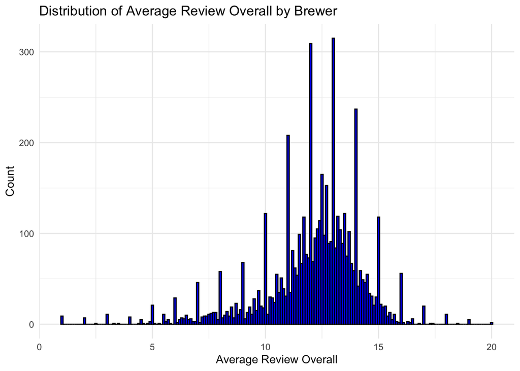

```r
avg.brewer = beer[, .(review_overall = mean(review_overall, na.rm = TRUE), num_reviews = .N), by = beer_brewerId]
ggplot(data = avg.brewer, aes(x = review_overall)) +
  geom_histogram(binwidth = 0.1, fill = "blue", color = "black") +
  labs(title = "Distribution of Average Review Overall by Brewer", x = "Average Review Overall", y = "Count") +
  scale_x_continuous() +
  theme_minimal()
```

```r
#Which are the best and worst brewer?
best.brewer = avg.brewer[review_overall == max(review_overall)]
worst.brewer = avg.brewer[review_overall == min(review_overall)]
best.brewer
```

| beer_brewerId | review_overall | num_reviews |
| --- | --- | --- |
| 811 | 20 | 1 |
| 9787 | 20 | 1 |

```r
worst.brewer
```

| beer_brewerId | review_overall | num_reviews |
| --- | --- | --- |
| 2551 | 1 | 1 |
| 4699 | 1 | 1 |
| 5045 | 1 | 1 |
| 3634 | 1 | 1 |
| 5253 | 1 | 1 |
| 3445 | 1 | 1 |
| 11696 | 1 | 1 |
| 8788 | 1 | 1 |
| 3603 | 1 | 1 |

```r
# with at least 10 reviews
best.brewer = avg.brewer[num_reviews >= 10][review_overall == max(review_overall)]
worst.brewer = avg.brewer[num_reviews >= 10][review_overall == min(review_overall)]
best.brewer
```

| beer_brewerId | review_overall | num_reviews |
| --- | --- | --- |
| 623 | 17.36493 | 422 |

```r
worst.brewer
```

| beer_brewerId | review_overall | num_reviews |
| --- | --- | --- |
| 1228 | 5.545455 | 11 |

Finally, let’s look at the relationship between beer styles and reviews:

14. Are breweries with a few or many beer styles those with higher reviews_overall?

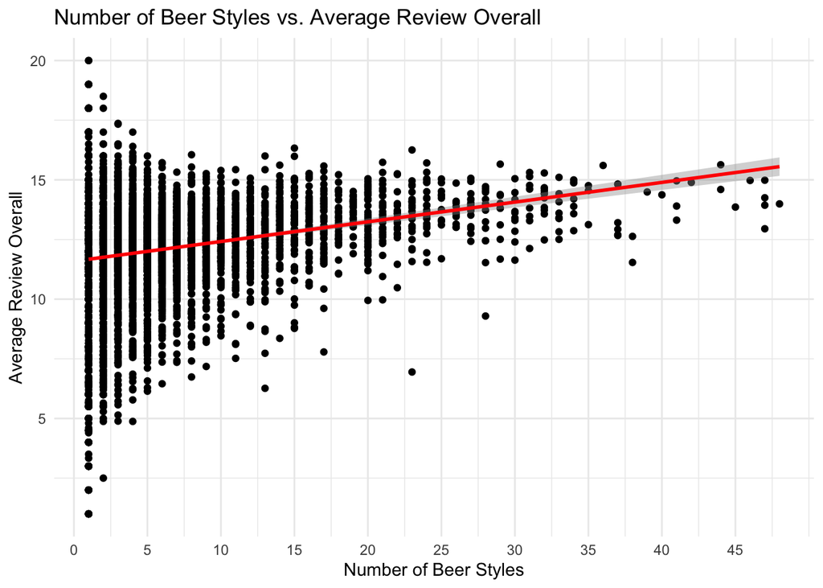

```r
avg.brewer.style = beer[, .(num_styles = uniqueN(beer_style), review_overall = mean(review_overall, na.rm = TRUE)), by = beer_brewerId]
ggplot(data = avg.brewer.style, aes(x = num_styles, y = review_overall)) +
  geom_point() +
  geom_smooth(method = "lm", color = "red") +
  labs(title = "Number of Beer Styles vs. Average Review Overall", x = "Number of Beer Styles", y = "Average Review Overall") +
  scale_x_continuous(breaks = seq(0, max(avg.brewer.style$num_styles, na.rm = TRUE), 5)) +
  theme_minimal()
```

Alternatively:

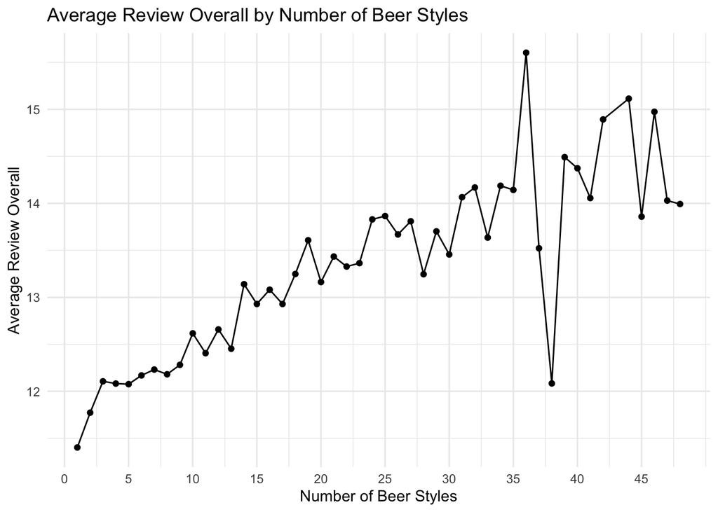

```r
# compute
temp = beer[, list(num_beer_style =length(unique(beer_style)),
                  avg_rating = mean(review_overall, na.rm=T)), by = beer_brewerId]
#compute average review_overall by num_beer_style
avg.brewer.style = temp[, .(avg_rating = mean(avg_rating, na.rm = TRUE)),
                         by = num_beer_style][order(-num_beer_style)]

ggplot(data = avg.brewer.style, aes(x = num_beer_style, y = avg_rating)) +
  geom_line() + geom_point() +
  labs(title = "Average Review Overall by Number of Beer Styles", x = "Number of Beer Styles", y = "Average Review Overall") +
  scale_x_continuous(breaks = seq(0, max(avg.brewer.style$num_beer_style), 5)) +
  scale_y_continuous(labels = scales::number_format(scale = 1)) +
  theme_minimal()
```

15. Suppose you were tasked with helping a brewery decide which and how many beers to produce. How can you use this data to answer these questions? You can utilize some of the analyses you performed above and also add new ones (for example, we did not examine time trends). Prepare a brief presentation that discusses the analyses supporting your decisions.